# EDA of SMUD Data for DUE-S Project

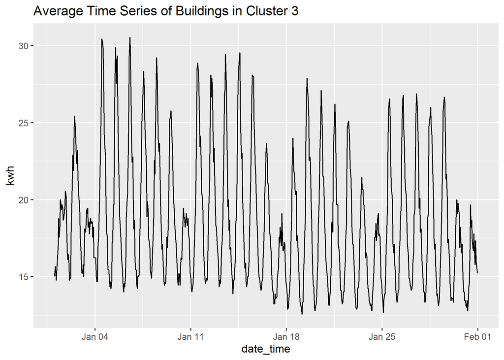

```r
building_energy_clusters %>%
  filter(cluster == k & year == y & month == m) %>%
  plot_time_var(kwh) +
  labs(
    title = str_glue("Average Time Series of Buildings in Cluster {k}")
  )
```

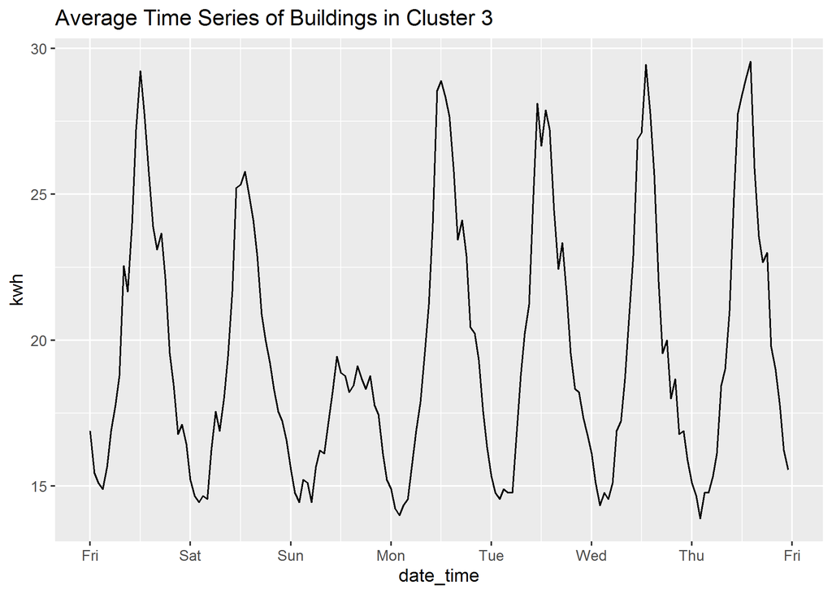

```r
building_energy_clusters %>%
  filter(cluster == k & year == y & week(date_time) == w) %>%
  plot_time_var(kwh) +
  scale_x_datetime(
    date_breaks = "1 day",
    date_labels = "%a",
  ) +
  labs(
    title = str_glue("Average Time Series of Buildings in Cluster {k}")
  )
```

We can also explore the relationship between clusters and our original non-temporal variables. Clear trends/differences can be seen, although it’s unclear if these variables could be used alone to generate effective clusters, especially in regards to the temporal shape/profile of energy usage patterns. Further, in our Fourier approach, it is possible to generate year-long time series with just a handful of Fourier coefficients and the inverse Fourier transform for each cluster, whereas the “average” time series for each cluster computed above may be noisy in comparison. The former method is not shown here/has not yet been implemented but is mentioned here for thoroughness and to convey the advantages of our methodology.

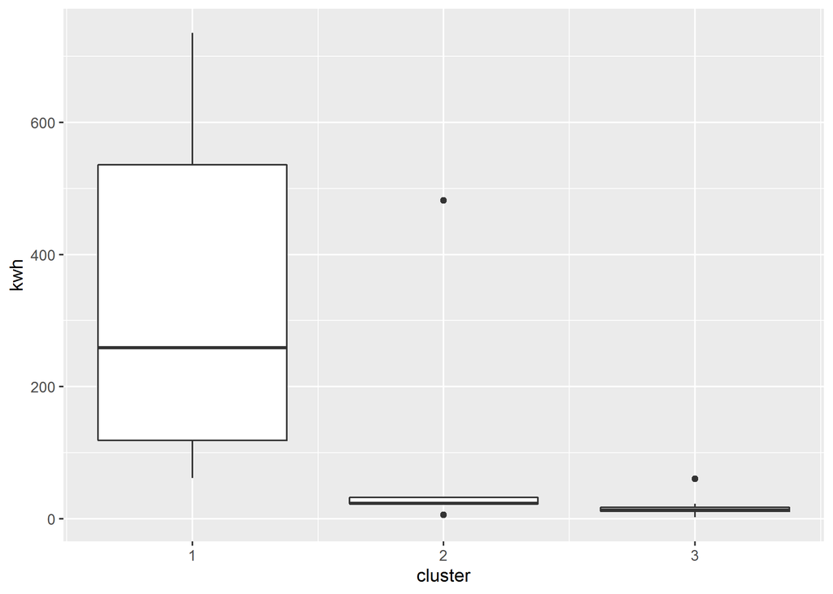

```r
building_profile <-
  building_energy %>%
  left_join(building_clusters, by = "id") %>%
  select_at(vars(-starts_with("PC"), -year, -month, -day, -hour, -freq)) %>%
  group_by(id) %>%
  summarize_if(is.numeric, mean, na.rm = TRUE)

cluster_boxplot <- function(df, var) {
  df %>%
    ggplot(aes(cluster, {{var}}, group = cluster)) +
    geom_boxplot()
}

building_profile %>%
  cluster_boxplot(kwh)
```

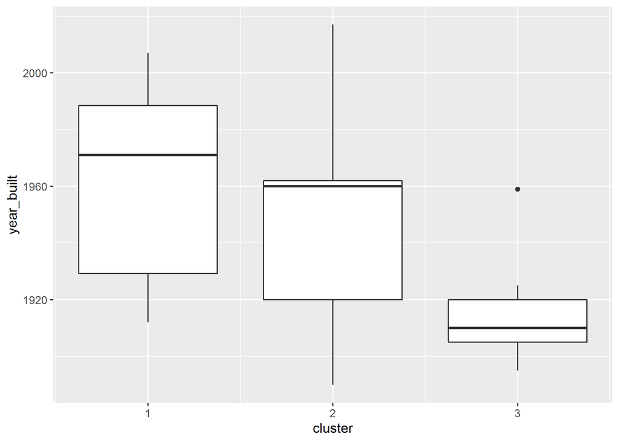

```r
building_profile %>%
  cluster_boxplot(year_built)
```

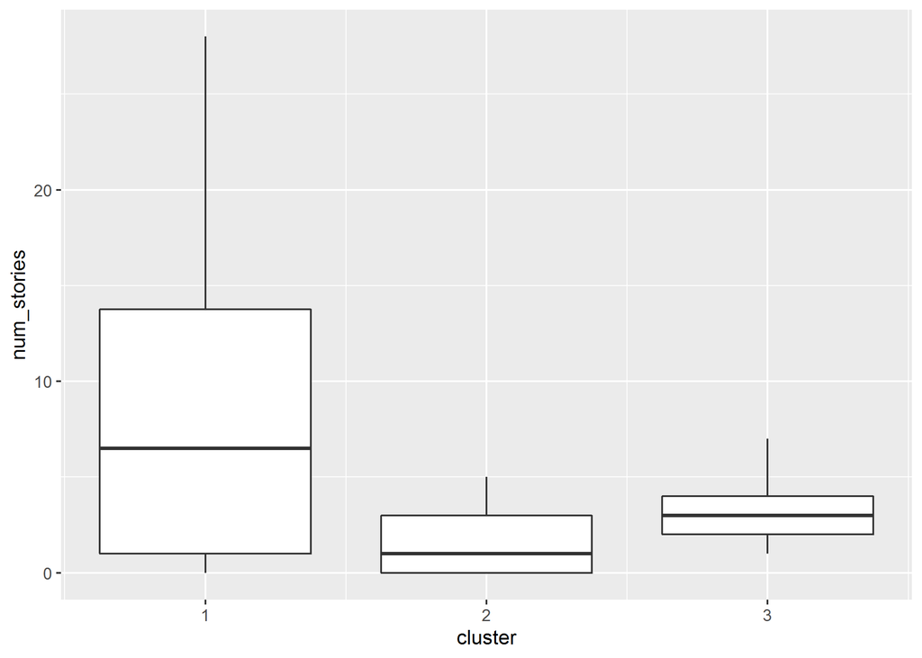

```r
building_profile %>%
  cluster_boxplot(num_stories)
```

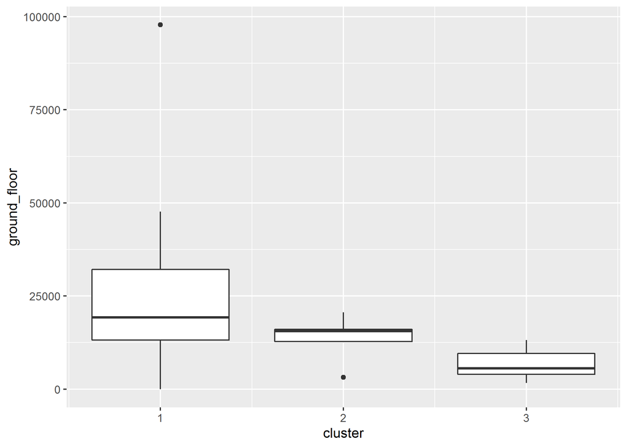

```r
building_profile %>%
  cluster_boxplot(ground_floor)
```

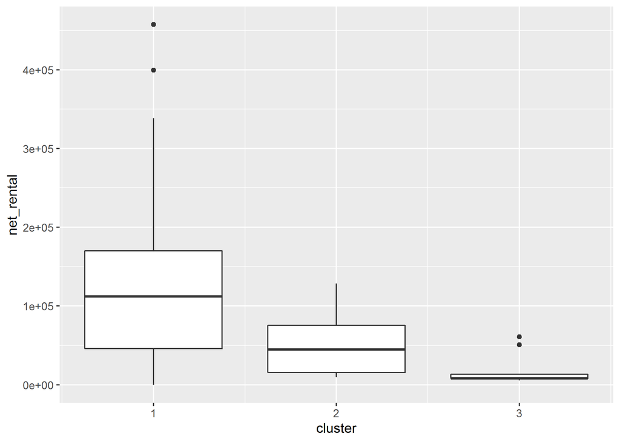

```r
building_profile %>%
  cluster_boxplot(net_rental)
```